# Introduction to using R package: `womblR`

Samuel I. Berchuck

2018-10-29

## Use of `womblR`

This is a brief description of how to use the `womblR` package within the context of glaucoma progression. We begin by loading the package.

```r
library(womblR)
```

In the `womblR` package there is a longitudinal series of visual fields that we will use to exemplify the statistical models contained in the package. The data object is called `VFSeries` and has four variables, `Visit`, `DLS`, `Time` and `Location`. The data object loads automatically; here’s what the data looks like,

```r
head(VFSeries)
```

```
##   Visit DLS Time Location
## 1     1  25    0        1
## 2     2  23  126        1
## 3     3  23  238        1
## 4     4  23  406        1
## 5     5  24  504        1
## 6     6  21  588        1
```

The variable `Visit` represents the visual field test visit number, `DLS` the observed outcome variable, differential light sensitvity, `Time` the time of the visual field test (in days from baseline visit) and `Location` the spatial location on the visual field that the observation occured. To help illuminate visual field data we can use the `PlotVFTimeSeries` function. `PlotVFTimeSeries` is a function that plots the observered visual field data over time at each location on the visual field.

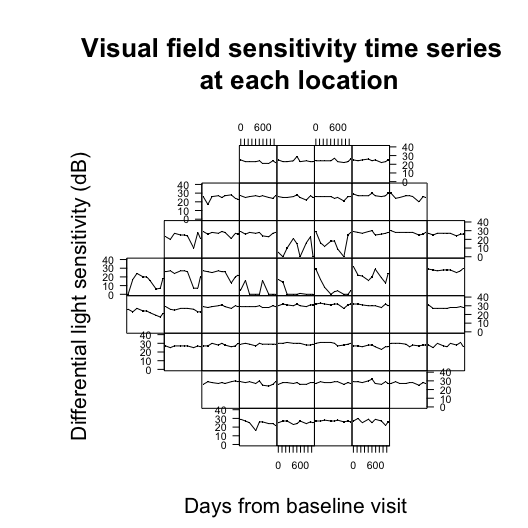

```r
PlotVfTimeSeries(Y = VFSeries$DLS,
                 Location = VFSeries$Location,
                 Time = VFSeries$Time,
                 main = "Visual field sensitivity time series \n at each location",
                 xlab = "Days from baseline visit",
                 ylab = "Differential light sensitivity (dB)",
                 line.col = 1, line.type = 1, line.reg = FALSE)
```

The figure above demonstrates the visual field from a Humphrey Field Analyzer-II testing machine, which generates 54 spatial locations (only 52 informative locations, note the 2 blanks spots corresponding to the blind spot). At each visual field test a patient is assessed for vision loss.

## Format data for `STBDwDM`

We can now begin to think about preparing objects for use in the the Spatiotemporal Boundary Detection with Dissimilarity Metric model function (`STBDwDM`). According to the manual, the observed data `Y` must be first ordered spatially and then temporally. Furthermore, we will remove all locations that correspond to the natural blind spot (which in the Humphrey Field Analyzer-II correspond to locations 26 and 35).

```r
blind_spot <- c(26, 35) # define blind spot
VFSeries <- VFSeries[order(VFSeries$Location), ] # sort by location
VFSeries <- VFSeries[order(VFSeries$Visit), ] # sort by visit
VFSeries <- VFSeries[!VFSeries$Location %in% blind_spot, ] # remove blind spot locations
Y <- VFSeries$DLS # define observed outcome data
```

Now that we have assigned the observed outcomed `Y` we move onto the temporal variable `Time`. For visual field data we define this to be the time from the baseline visit. We obtain the unique days from the baseline visit and scale them to be on the year scale.

```r
Time <- unique(VFSeries$Time) / 365 # years since baseline visit
print(Time)
```

```
## [1] 0.0000000 0.3452055 0.6520548 1.1123288 1.3808219 1.6109589 2.0712329
## [8] 2.3780822 2.5698630
```

Our example patient has nine visual field visits and the last visit occured 2.57 years after the baseline visit.

## Adjacency matrix and dissimilarity metric

We now specify the adjacency matrix, `W`, and dissimilarity metric, `DM`. There are three adjacency matrices for the Humphrey Field Analyzer-II visual field that are supplied by the `womblR` package, `HFAII_Queen`, `HFAII_QueenHF`, and `HFAII_Rook`. `HFAII_Queen` and `HFAII_QueenHF` both define adjacencies as edges and corners (i.e., the movements of a queen in chess), while `HFAII_Rook` only defines an adjacency as a neighbor that shares an edge (i.e., a rook in chess). The `HFAII_QueenHF` adjacency matrix does not allow neighbors to share information between the northern and southern hemispheres of the visual field. In this analysis we use the standard queen specification. The adjacency objects are preloaded and contain the blind spot, so we define our adjacency matrix as follows.

```r
W <- HFAII_Queen[-blind_spot, -blind_spot] # visual field adjacency matrix
```

Now we turn our attention to assigning a dissimilarity metric. The dissimilarity metric we use in this data application are the Garway-Heath angles that describe the underlying location that the retinal nerve fibers enter the optic disc. These angles (measured in degrees) are included with `womblR` in the object `GarwayHeath`. We create the dissimilarity metric object `DM`.

```r
DM <- GarwayHeath[-blind_spot] # Garway-Heath angles
```

The `womblR` package provides a plotting function `PlotAdjacency` that can be used to display a dissimilarity metric over the spatial structure of the visual field. We demonstrate it using the Garway-Heath angles.

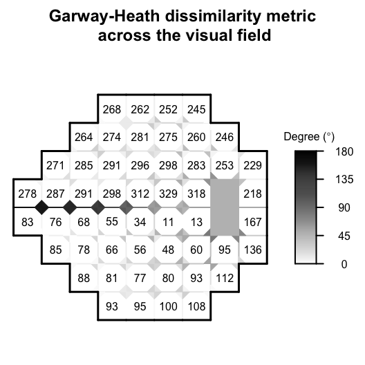

```r
PlotAdjacency(W = W, DM = DM, zlim = c(0, 180), Visit = NA,
              main = "Garway-Heath dissimilarity metric\n across the visual field")
```

Now that we have specified the data objects `Y`, `DM`, `W` and `Time`, we will customize the objects that characterize Bayesian Markov chain Monte Carlo (MCMC) methods, in particular hyperparameters, starting values, metroplis tuning values and MCMC inputs.

## MCMC Characteristics

We begin be specifying the hyperparameters for the model. The parameter $\phi$ is uniformly distributed with bounds, $a_{\phi}$ and $b_{\phi}$. The bounds for $\phi$ cannot be specified arbitrarily since it is important to account for the magnitude of time elapsed. We specify the following upper and lower bounds for $\phi$ to dictate temporal correlation close to independence or strong correlation, resulting in a weakly informative prior distribution.

```r
TimeDist <- abs(outer(Time, Time, "-"))
TimeDistVec <- TimeDist[lower.tri(TimeDist)]
minDiff <- min(TimeDistVec)
maxDiff <- max(TimeDistVec)
PhiUpper <- -log(0.01) / minDiff # shortest diff goes down to 1%
PhiLower <- -log(0.95) / maxDiff # longest diff goes up to 95%
```

Then, we can create a hyperparameters `list` object, `Hypers`, that can be used for `STBDwDM`.

```r
Hypers <- list(Delta = list(MuDelta = c(3, 0, 0), OmegaDelta = diag(c(1000, 1000, 1))),
               T = list(Xi = 4, Psi = diag(3)),
               Phi = list(APhi = PhiLower, BPhi = PhiUpper))
```

Here, $\delta$ has a multivariate normal distribution with mean parameter $\boldsymbol{\mu}_{\delta}$ and covariance, $\boldsymbol{\Omega}_{\delta}$ and $\mathbf{T}$ has an inverse-Wishart distribution with degrees of freedom $\xi$ and scale matrix, $\Psi$ (See the help manual for `STBDwDM` for further details).

Specify a `list` object, `Starting`, that contains the starting values for the hyperparameters.

```r
Starting <- list(Delta = c(3, 0, 0), T = diag(3), Phi = 0.5)
```

Provide tuning parameters for the metropolis steps in the MCMC sampler.

```r
Nu <- length(Time) # calculate number of visits
Tuning <- list(Theta2 = rep(1, Nu), Theta3 = rep(1, Nu), Phi = 1)
```

We set `Tuning` to the default setting of all ones and let the pilot adaptation in the burn-in phase tune the acceptance rates to the appropriate range. Finally, we set the MCMC inputs using the `MCMC` list object.

```r
MCMC <- list(NBurn = 10000, NSims = 10000, NThin = 10, NPilot = 20)
```

We specify that our model will run for a burn-in period of 10,000 scans, followed by 10,000 scans after burn-in. In the burn-in period there will be 20 iterations of pilot adaptation evenly spaced out over the period. Finally, the final number of samples to be used for inference will be thinned down to 1,000 based on the thinning number of 10. We suggest running the sampler 250,000 iterations after burn-in, but in the vignette we are limited by compilation time.

## Spatiotemporal boundary dection with dissimilarity metric model

We have now specified all model objects and are prepared to implement the `STBDwDM` regression object. To demonstrate the `STBDwDM` object we will use all of its options, even those that are being used in their default settings.

```r
reg.STBDwDM <- STBDwDM(Y = Y, DM = DM, W = W, Time = Time,
                       Starting = Starting, Hypers = Hypers, Tuning = Tuning, MCMC = MCMC,
                       Family = "tobit",
                       TemporalStructure = "exponential",
                       Distance = "circumference",
                       Weights = "continuous",
                       Rho = 0.99,
                       ScaleY = 10,
                       ScaleDM = 100,
                       Seed = 54)
## Burn-in progress:  |*************************************************|
## Sampler progress:  0%..  10%..  20%..  30%..  40%..  50%..  60%..  70%..  80%..  90%..  100%..
```

The first line of arguments are the data objects, `Y`, `DM`, `W`, and `Time`. These objects must be specified for `STBDwDM` to run. The second line of objects are the MCMC characteristics objects we defined previously. These objects do not need to be defined for `STBDwDM` to function, but are provided for the user to custimize the model to their choosing. If they are not provided, defaults are given. Next, we specify that `Family` be equal to `tobit` since we know that visual field data is censored. Furthermore, we specify `TemporalStructure` to be the `exponential` temporal correlation structure. Our distance metric on the visual field is based on the circumference of the optic disc, so we define `Distance` to be `circumference`. Then, the adjacency weights are specified to be `continuous`, as opposed to the `binary` specification of Lee and Mitchell (2011). Finally, we define the following scalar variables, `Rho`, `ScaleY`, `ScaleDM`, and `Seed`, which are defined in the manual for `STBDwDM`.

The following are the returned objects from `STBDwDM`.

```r
names(reg.STBDwDM)
```

```
##  [1] "mu"         "tau2"       "alpha"      "delta"      "T"
##  [6] "phi"        "metropolis" "datobj"     "dataug"     "runtime"
```

The object `reg.STBDwDM` contains raw MCMC samples for parameters $\mu_t$ (`mu`), $\tau_t^2$ (`tau2`), $\alpha_{tGH}$ (`alpha`), $\boldsymbol{\delta}$ (`delta`), $\mathbf{T}$ (`T`) and $\phi$ (`phi`), metropolis acceptance rates and final tuning parameters (`metropolis`) and model runtime (`runtime`). The objects `datobj` and `dataug` can be ignored as they are for later use in secondary functions.

## Assessing model convergence

Before analyzing the raw MCMC samples from our model we want to verify that there are no convergence issues. We begin by loading the `coda` package.

```r
library(coda)
```

Then we convert the raw `STBDwDM` MCMC objects to `coda` package `mcmc` objects.

```r
Mu <- as.mcmc(reg.STBDwDM$mu)
Tau2 <- as.mcmc(reg.STBDwDM$tau2)
Alpha <- as.mcmc(reg.STBDwDM$alpha)
Delta <- as.mcmc(reg.STBDwDM$delta)
T <- as.mcmc(reg.STBDwDM$T)
Phi <- as.mcmc(reg.STBDwDM$phi)
```

We begin by checking traceplots of the parameters. For conciseness, we present one traceplot for each parameter type.

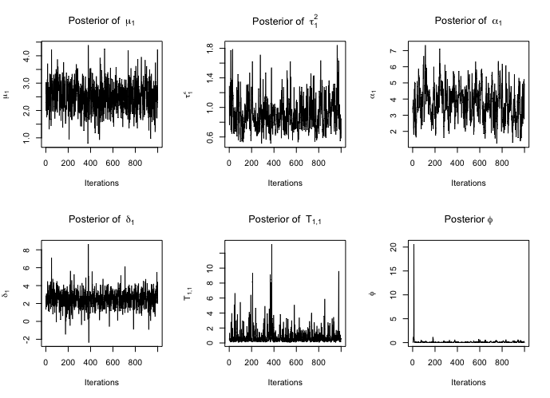

From the figure, it is clear that the traceplots exhibit some poor behavior. However, these traceplots are nicely behaved considering the number of iterations the MCMC sampler ran. The traceplots demonstrate that the parameters have converged to their stationary distribution, but still need more samples to rid themselves of autocorrelation. Finally, we present the corresponding test statistics from the Geweke diagnostic test.

```
##       mu1     tau21    alpha1    delta1       t11       phi
## 0.8859090 0.6506118 0.4813725 0.7604529 0.8876281 0.9209661
```

Since none of these test statistics are terribly large in the absolute value there is not strong evidence that our model did not converge.

## Post model fit analysis

Once we have verified that we do not have any convergence issues, we can begin to think about analyzing the raw MCMC samples. A nice summary for `STBDwDM` is to plot the posterior mean of each of the level 1 parameters over time.

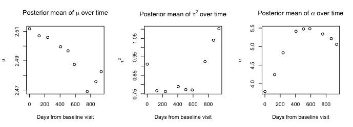

This figure gives a nice summary of the model findings. In particular, the plot of the $\alpha_{tGH}$ demonstrate a non-linear trend and the capabilty of `STBDwDM` to smooth temporal effects. We now demonstrate how to calculate the posterior distribution of the coefficient of variation (cv) of $\alpha_{tGH}$.

```r
CVAlpha <- apply(Alpha, 1, cv <- function(x) sd(x) / mean(x))
STCV <- c(mean(CVAlpha), sd(CVAlpha), quantile(CVAlpha, probs = c(0.025, 0.975)))
names(STCV)[1:2] <- c("Mean", "SD")
print(STCV)
```

```
##       Mean         SD       2.5%      97.5%
## 0.19087953 0.10325070 0.04504396 0.40886479
```

STCV (i.e., the posterior mean) was shown to be predictive of glaucome progression, so it is important to be able to compute this value. Here STCV is calculated to be 0.19.

Another component of the model that is important to explore are the adjacencies themselves, $w_{ij}$. As a function of $\alpha_{tGH}$ these adjacencies can be calculated generally, and the `womblR` function has provided a function `PosteriorAdj` to compute them.

```r
Wij <- PosteriorAdj(reg.STBDwDM)
```

The function `PosteriorAdj` function takes in the `STBDwDM` regression object and returns a `PosteriorAdj` object that contains the posterior mean and standard deviation for each adjacency at each visit.

```r
Wij[1:6, 1:7]
```

```
##      i j DM     mean1        sd1     mean2        sd2
## [1,] 1 2  6 0.7981359 0.04875009 0.7765727 0.04479334
## [2,] 2 3 10 0.6881660 0.06995050 0.6573147 0.06274004
## [3,] 3 4  7 0.7689777 0.05477419 0.7447670 0.05001735
## [4,] 1 5  4 0.8600777 0.03505531 0.8445508 0.03262409
## [5,] 1 6  6 0.7981359 0.04875009 0.7765727 0.04479334
## [6,] 2 6 12 0.6393951 0.07794788 0.6050696 0.06911669
```

For visual field data, the function `PlotAdjacency` can be used to plot the mean and standard deviations of the adjacencies at each of the visits over the visual field surface. We plot the mean adjacencies at visit 3.

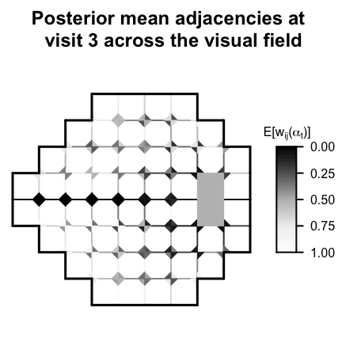

```r
ColorScheme1 <- c("Black", "#636363", "#bdbdbd", "#f0f0f0", "White")
PlotAdjacency(Wij, Visit = 3, stat = "mean",
              main = "Posterior mean adjacencies at \n visit 3 across the visual field",
              color.scheme = ColorScheme1)
```

And now, we plot the standard deviation of the adjacencies at visit 4.

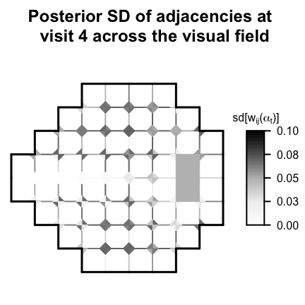

```r
ColorScheme2 <- rev(ColorScheme1)
zlimSD <- quantile(Wij[,c(5,7,9,11,13,15,17,19,21)], probs = c(0, 1))
PlotAdjacency(Wij, Visit = 4, stat = "sd",
              main = "Posterior SD of adjacencies at \n visit 4 across the visual field",
              zlim = zlimSD, color.scheme = ColorScheme2)
```

The function `PlotAdjacency` provides a visual tool for assessing change on the visual field over time.

## Compute diagnostics

The `diagnostics` function in the `womblR` package can be used to calculate various diagnostic metrics. The function takes in the `STBDwDM` regression object.

```r
Diags <- diagnostics(reg.STBDwDM, diags = c("dic", "dinf", "waic"), keepDeviance = TRUE)
```

```
## Calculating Log-Lik: 0%.. 25%.. 50%.. 75%.. 100%.. Done!
## Calculating PPD: 0%.. 25%.. 50%.. 75%.. 100%.. Done!
```

The `diagnostics` function calculates diagnostics that depend on both the log-likelihood and posterior predictive distribtuion. So, if any of these diagnostics are specified, one or both of these must be sampled from. The `keepDeviance` and `keepPPD` indicate whether or not these distributions should be saved for the user. We indicate that we would like the output to be saved for the log-likelihood (i.e., deviance). We explore the output by looking at the traceplot of the deviance.

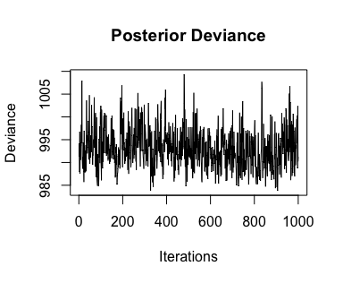

```r
Deviance <- as.mcmc(Diags$deviance)
traceplot(Deviance, ylab = "Deviance", main = "Posterior Deviance")
```

This distribution has converged nicely, which is not surprising, given that the other model parameters have converged. Now we can look at the diagnostics.

```r
print(Diags)
```

```
##         dic          pd
## 1001.049837    8.050672
```

```
##        p        g     dinf
## 121068.4 250009.9 371078.4
```

```
##        waic      p_waic        lppd    p_waic_1
##  998.839144    4.520054 -494.899518    3.200130
```

## Future prediction

The `womblR` package provides the `predict.STBDwDM` function for sampling from the posterior predictive distribution at future time points of the observed data. This is different from the posterior predictive distribution obtained from the `diagnostics` function, because that distribution is for the observed time points and is automatically obtained given the posterior samples from `STBDwDM`. In order to obtain future samples, you first need samples from the posterior distribution of the future $\mu_t$, $\tau_t^2$, and $\alpha_t$ parameters. The `predict.STBDwDM` first samples these parameters and then samples from the future distribution of the observed outcome variable, returning both. We begin by specifying the future time points we want to predict as 50 and 100 days past the most recent visit.

```r
NewTimes <- Time[Nu] + c(50, 100) / 365
```

Then, we use `predict.STBDwDM` to calculate the future posterior predictive distribution.

```r
Predictions <- predict(reg.STBDwDM, NewTimes)
```

```
## Krigging Thetas: 0%.. 25%.. 50%.. 75%.. 100%.. Done!
## Krigging Y: 0%.. 25%.. 50%.. 75%.. 100%.. Done!
```

We can see that `predict.STBDwDM` returns a `list` containing two `lists`.

```r
names(Predictions)
```

```
## [1] "MuTauAlpha" "Y"
```

The object `MuTauAlpha` is a `list` containing three matrices with the posterior distributions of the future level 1 parameters.

```r
names(Predictions$MuTauAlpha)
```

```
## [1] "mu"    "tau2"  "alpha"
```

```r
head(Predictions$MuTauAlpha$alpha)
```

```
##       alpha10  alpha11
## [1,] 6.549409 5.749063
## [2,] 5.723072 5.774788
## [3,] 3.137910 2.815721
## [4,] 4.941708 5.302214
## [5,] 8.860209 9.004541
## [6,] 3.891100 4.136476
```

While the object `Y` is a `list` containing however many matrices correspond to the number of new future time points (here: 2).

```r
names(Predictions$Y)
```

```
## [1] "y10" "y11"
```

You can plot a heat map representation of the posterior prediction distribution using the function `PlotSensitivity`.

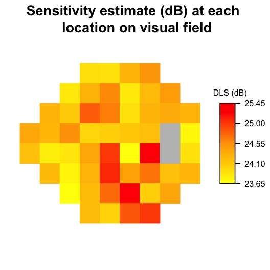

```r
PlotSensitivity(Y = apply(Predictions$Y$y10, 2, median),
                main = "Sensitivity estimate (dB) at each \n location on visual field",
                legend.lab = "DLS (dB)", legend.round = 2,
                bins = 250, border = FALSE)
```

This figure shows the median posterior predictive heat map over the visual field at the future visit in 50 days past the final observed visit. The `PlotSensitivity` function can be used for plotting any observations on the visual field surface.